# El lenguaje de programación R - Graficación

### Gráficos de barras

Los [gráficos de barras (*barcharts* o *barplots*)](https://www.data-to-viz.com/graph/barplot.html) muestran la relación entre una variable categórica y una variable numérica. Cada entidad de la variable categórica es representada mediante una barra, en la que su altura representa el valor correspondiente de la variable numérica.

Para los ejemplos de esta sección, se utilizará el conjunto de datos de casos de COVID-19 de Centroamérica y República Dominicana. Para facilitar su visualización, se ordenan los registros de acuerdo con la columna de casos confirmados, mediante la función [order()](https://www.rdocumentation.org/packages/base/versions/3.6.2/topics/order).

```r
# Ordenar de mayor a menor
ca_positivos.ordenado <- order(ca_covid19$positivos, decreasing=TRUE)

# Nuevo data frame ordenado
ca_covid19.positivos <- ca_covid19[ca_positivos.ordenado,]
```

La función [barplot()](https://www.rdocumentation.org/packages/graphics/versions/3.6.2/topics/barplot), del paquete graphics, se utiliza en el siguiente ejemplo para generar un gráfico de barras de los casos confirmados.

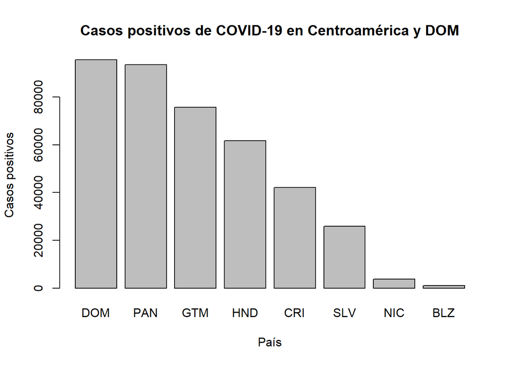

```r
barplot(
  height=ca_covid19.positivos$positivos,
  names.arg=ca_covid19.positivos$pais,
  xlab="País",
  ylab="Casos positivos",
  main="Casos positivos de COVID-19 en Centroamérica y DOM"
)
```

La función [geom_col()](https://ggplot2.tidyverse.org/reference/geom_bar.html), en combinación con `ggplot()`, puede utilizarse para generar gráficos de barras.

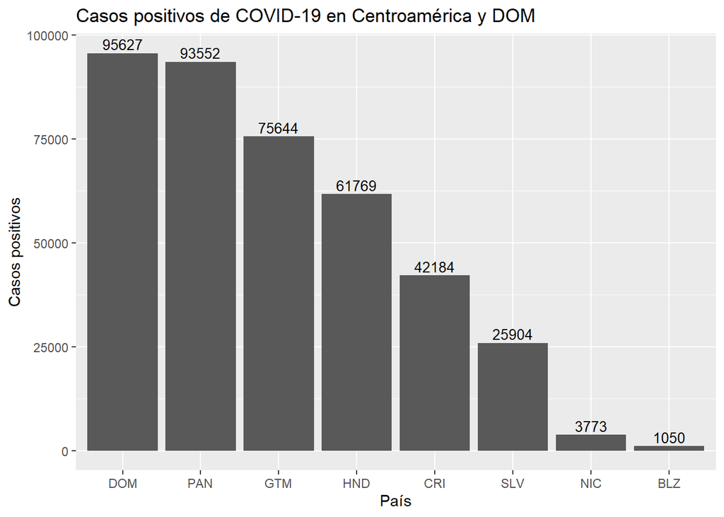

```r
ggplot(ca_covid19, aes(x=reorder(pais, -positivos), y=positivos)) +
  ggtitle("Casos positivos de COVID-19 en Centroamérica y DOM") +
  xlab("País") +
  ylab("Casos positivos") +
  geom_col() +
  geom_text(aes(label=positivos), vjust=-0.3, size=3.5)
```

Note el uso de la función [reorder()](https://www.r-graph-gallery.com/267-reorder-a-variable-in-ggplot2.html) en el ejemplo anterior, para ordenar el orden de las barras (i.e. los países) en el eje X y el de [geom_text()](https://ggplot2.tidyverse.org/reference/geom_text.html) para desplegar etiquetas sobre las barras.